# Краткое введение в мир матричной алгебры

## Важное свойство сингулярных чисел

Если вычислить матрицу на основе не всех, а части сингулярных чисел, то новая матрица будет подобна исходной матрице.

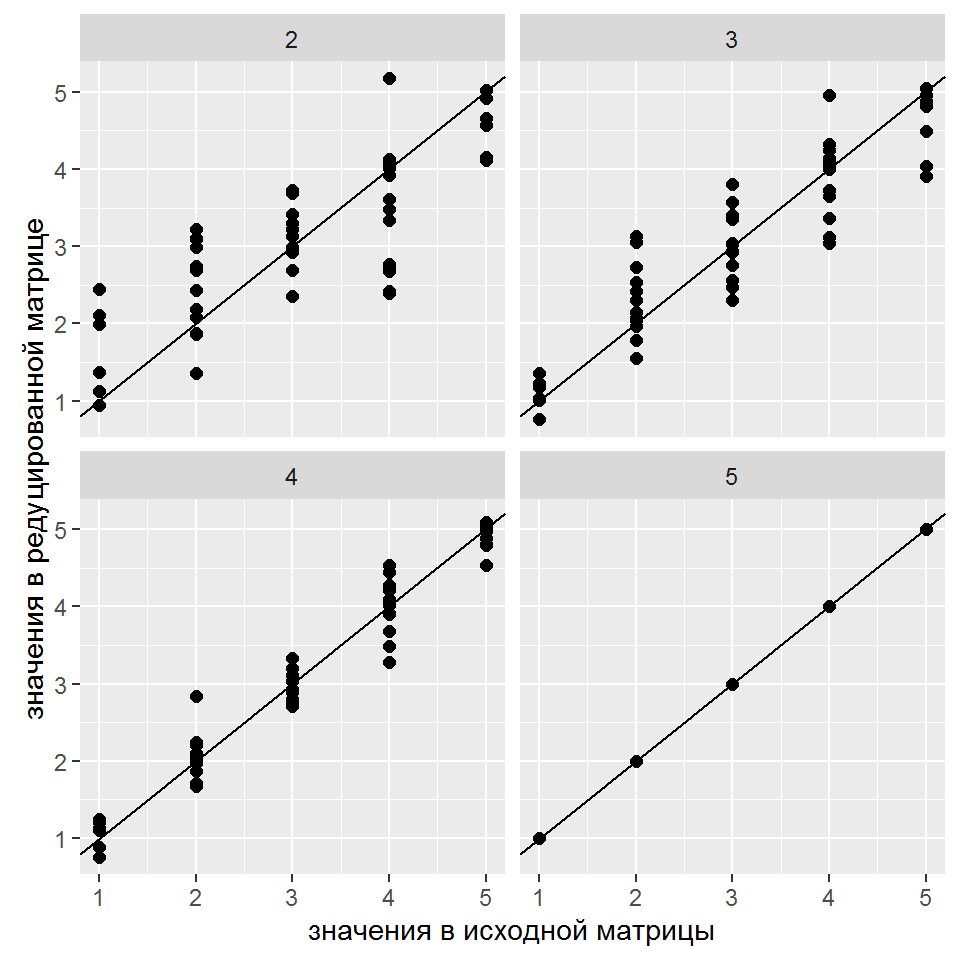

## Применение свойства сингулярных чисел в сжатии изображений

Пример взят из курса лекций "Data Analysis" by Jeffrey Leek (https://github.com/jtleek/dataanalysis/tree/master/week3)

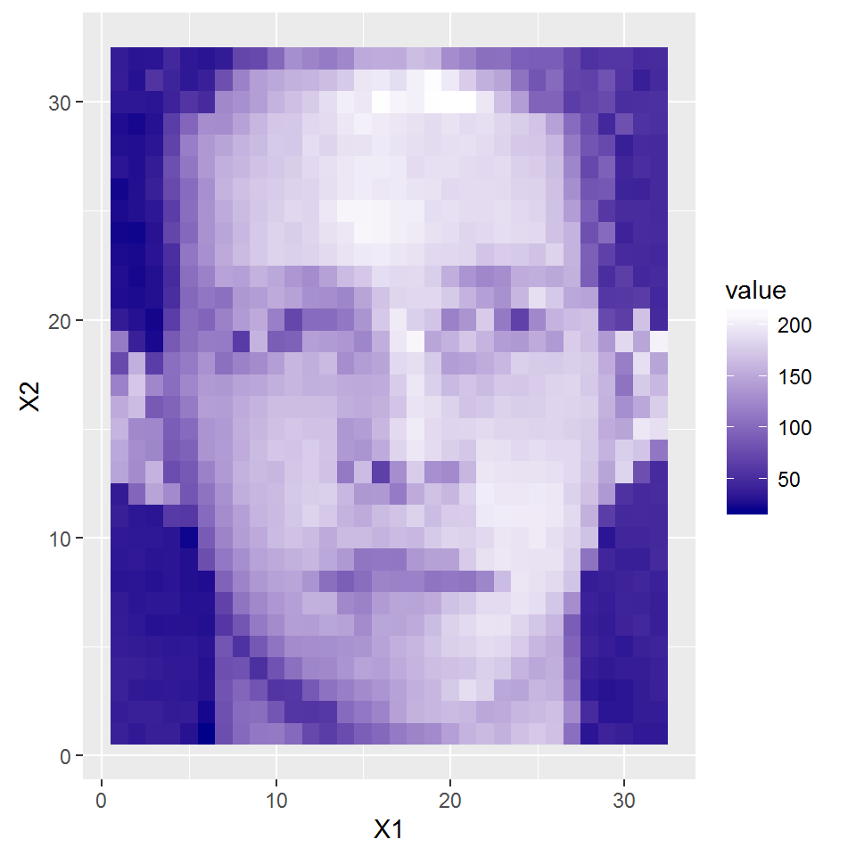

## Произведем сингулярное разложение матрицы `faceData`

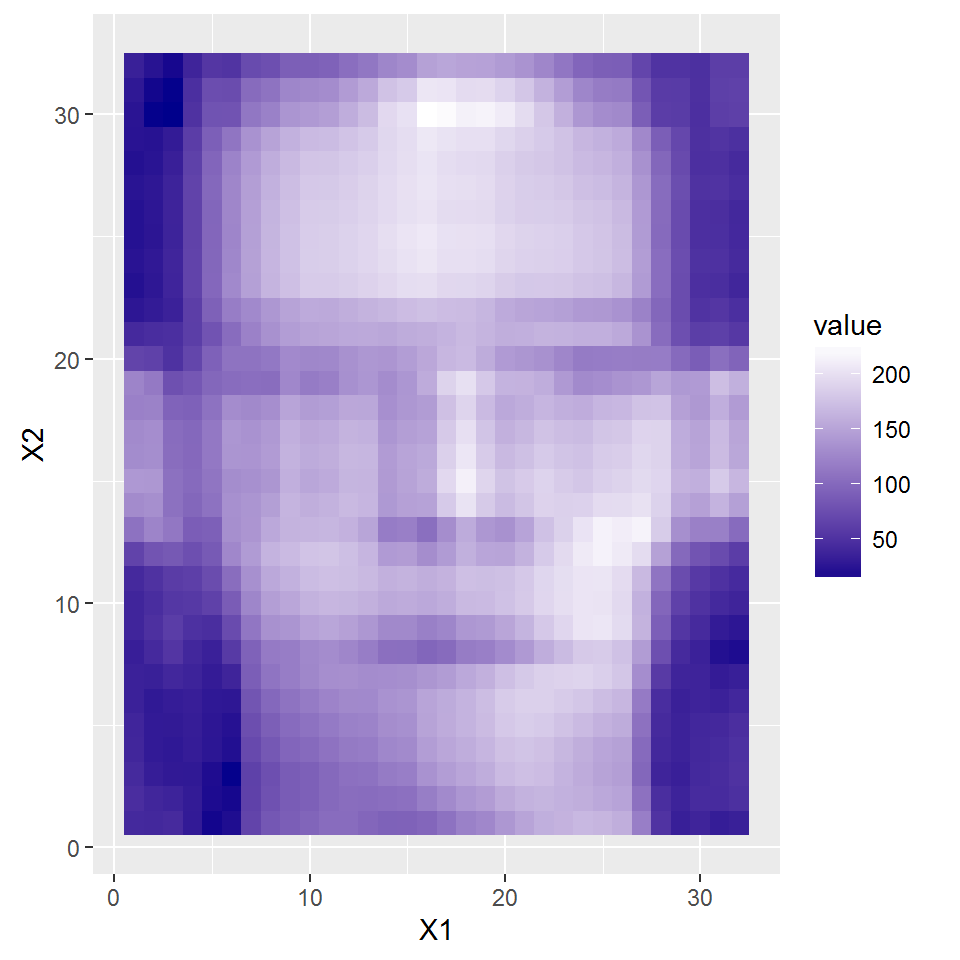

```r
SVD_face <- svd(faceData)

U <- SVD_face$u
D <- SVD_face$d
V <- SVD_face$v

reduction <- function(x) U[,1:x] %*% diag(D[1:x]) %*% t(V[, 1:x])

gg_face(reduction(4))
```

## Применение SVD в биологических исследованиях

SVD - это метод, на котором основаны разные типы анализа, связанные со снижением размерности: PCA, CCA.

О них в следующей лекции

## Summary

- Матричная алгебра позволяет решать самые разные типы задач.
- Матричные методы лежат в основе очень многих типов анализа.
- В основе многих методов снижения размерности лежит SVD.

## Что почитать

- Legendre P., Legendre L. (2012) Numerical ecology. Second english edition. Elsevier, Amsterdam. Глава 2. Matrix algebra: a summary.

## Not The End

[figure not shown]